# Simulating the Exponential Distribution

Dhruv Mishra

Wednesday, April 22, 2015

## Synopsis

This report investigates the exponential distribution in R and compares it with the Central Limit Theorem. The exponential distribution can be simulated in R with `rexp(n, lambda)` where `lambda` $\lambda$ is the rate parameter. The mean of exponential distribution is $1/\lambda$ and the standard deviation is also $1/\lambda$. For this simulation, we set $\lambda=0.2$. In this simulation, we investigate the distribution of averages of 40 numbers sampled from exponential distribution with $\lambda=0.2$.

The number of samples taken is 40 which are simulated a thousand times.

## Simulations

Using the numerical values stated above, the code below evaluates the `rexp(n, lambda)` function a thousand times and stores the mean of each iteration in the `means` data frame.

```r
set.seed(31)

## set constants
nosim <- 1:1000
n <- 40
lambda <- 0.2

## simulate the means
means <- data.frame(m = sapply(nosim, function(x) {
    mean(rexp(n, lambda))
}))
```

## Sample Mean versus Theoretical Mean

The mean of the means data frame is the sample mean while the theoretical mean is $1/\lambda$

```r
#sample mean
sample.mean <- mean(means$m)
#theoretical mean
theoretical.mean <- 1/lambda
```

The sample mean is **4.9938666** and the theoretical mean is **5**. They are very close, as expected by the Central Limit Theorem(CLT).

```r
## sample variance
sample.var <- var(means$m)
## theoretical variance
theoretical.var <- ((1/lambda)/sqrt(40))^2
```

## Distribution

Also, according to the CLT, the distribution of the simulated means should be approximately normal. To illustrate this we will normalize the vectors and compare it to a $N(0,1)$ distribution.

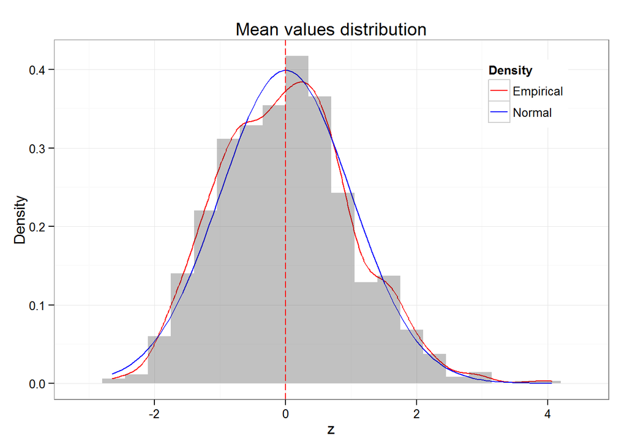

```r
library(ggplot2)
zmean <- (means$m - sample.mean) / sqrt(sample.var)
qplot(zmean, geom = "blank") +
    geom_line(aes(y = ..density.., colour = 'Empirical'), stat = 'density') +
    stat_function(fun = dnorm, aes(colour = 'Normal')) +
    geom_histogram(aes(y = ..density..), , alpha = 0.3, binwidth=.35) +
    geom_vline(xintercept=0, colour="red", linetype="longdash") +
    scale_colour_manual(name = 'Density', values = c('red', 'blue')) +
    ylab("Density") + xlab("z") + ggtitle("Mean values distribution") +
    theme_bw() + theme(legend.position = c(0.85, 0.85))
```